# Local Authority Housing Statistics - Data Cleaning Script

Josh Cowley

March 27, 2022

```r
source(file.path("data-raw", "LAHS-data-cleaning-helper.R"))
```

The purpose of this report is to convey all processes used and any decisions made when the data was cleaned. The source of this data (CSV) can be found at https://www.gov.uk/government/statistical-data-sets/local-authority-housing-statistics-open-data.

Currently, we are interested in a subset of these data and as such will populate a new data frame as we clean the data.

```r
lahs_path <-
  file.path("data-raw", "source", "LAHS_201112_to_202021_open_data_02_2022.csv")

lahs_csv <- utils::read.csv(lahs_path)

LAHS <- tibble::tibble(.rows = nrow(lahs_csv))
```

# 1 Local Authority Information

## 1.1 Unique Identifiers

We use the local authority code and name at the time of data collection, ignoring the codes and names using the 2020 geography

```r
LAHS$LA_CODE <- lahs_csv$LA_CODE
LAHS$LA_NAME <- lahs_csv$LA_NAME
```

There are 332 unique local authorities. Most have 10 data points, one for each year, but this is not always the case. The following visualisation summarises the LA(s) that have fewer than 10 observations.

**Reveal ggplot2 code.**

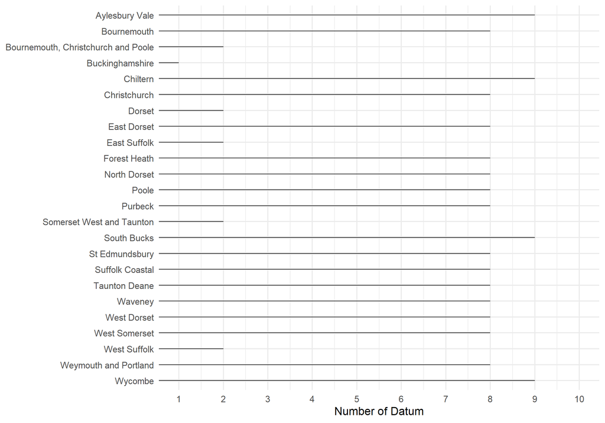

```r
LAHS %>%
  dplyr::count(.data$LA_NAME) %>%
  dplyr::filter(.data$n != 10) %>%
  ggplot2::ggplot(ggplot2::aes(
    y = forcats::fct_rev(factor(.data$LA_NAME)),
    xmax = .data$n,
  )) +
  ggplot2::geom_linerange(xmin = 0) +
  ggplot2::scale_x_continuous(breaks = 1:10, limits = c(1, 10)) +
  ggplot2::labs(y = NULL, x = "Number of Datum")
```

## 1.2 Classification

We are also interested in the categorical information that is held in the first three characters of the local authority code and in its own column.

For example, Darlington is coded “E06000005”; the “E06” implies that this LA is a unitary authority. We convert each code to a corresponding label.

```r
LAHS$LA_TYPE <- parse_la_type(lahs_csv$LAD20TYPE)
```

We can see the respective sample sizes of such divisions here.

**Reveal table generating code.**

```r
dplyr::count(LAHS, .data$LA_TYPE) %>%
  kableExtra::kbl(col.names = c("Local Authority Type", "N"), align = "lr") %>%
  kableExtra::kable_styling()
```

| Local Authority Type | N |
| --- | --- |
| Unitary authority | 609 |
| Lower tier district authority | 1940 |
| Metropolitan local authority | 360 |
| London borough | 330 |

A further classification can be made on the region each LA exists in.

```r
LAHS$LA_REGION <- lahs_csv$RGN20NM
```

With a similar table also made.

**Reveal table generating code.**

```r
dplyr::count(LAHS, .data$LA_REGION) %>%
  kableExtra::kbl(col.names = c("English Region", "N"), align = "lr") %>%
  kableExtra::kable_styling()
```

| English Region | N |
| --- | --- |
| East Midlands | 400 |
| East of England | 466 |
| London | 330 |
| North East | 120 |
| North West | 390 |
| South East | 667 |
| South West | 356 |
| West Midlands | 300 |
| Yorkshire and The Humber | 210 |

# 2 Temporal Information

```r
LAHS$YEAR <-
  lahs_csv$Year %>%
  regmatches(regexpr("^20[0-9]{2}", .)) %>%
  as.integer()
```

# 3 Section A: Dwelling Stock

Section A, as described in the LAHS guidance document informs about the number and value of dwellings within the LA.

## 3.1 Ownership

Questions a.1.a) and a.1.b) relate to any publicly owned property within a LA, whereas a.2.i.a) relates to all stock owned by the corresponding LA with option to dig deeper into how many are “Social Rent” against “Affordable Rent”.

```r
LAHS$STOCK_PUBLIC_LA <- lahs_csv$a1a
LAHS$STOCK_PUBLIC_OTHER <- lahs_csv$a1b
LAHS$STOCK <- lahs_csv$a2ia
```

Now, we see many of the data points concern local auhthorities that own no dwelling stock and thus will be unusable.

**Reveal table generating code.**

```r
local({
  raw_stock_table <-
    LAHS %>%
    dplyr::count(g = ceiling(.data$STOCK / 1e4)) %>%
    dplyr::mutate(
      lower = prettyNum(1e4 * (g - 1) + 1, big.mark = ","),
      upper = prettyNum(1e4 * g, big.mark = ","),
      stock_tb = paste(.data$lower, .data$upper, sep = " - "),
      .before = 1, .keep = "unused"
    )

  raw_stock_table$stock_tb[1] <- "No dwellings owned"

  raw_stock_table %>%
    dplyr::select(.data$stock_tb, .data$n) %>%
    kableExtra::kbl(col.names = c("Owned Stock", "N"), align = "lr") %>%
    kableExtra::kable_styling()
})
```

| Owned Stock | N |
| --- | --- |
| No dwellings owned | 1520 |
| 1 - 10,000 | 1162 |
| 10,001 - 20,000 | 346 |
| 20,001 - 30,000 | 170 |
| 30,001 - 40,000 | 16 |
| 40,001 - 50,000 | 5 |
| 50,001 - 60,000 | 11 |
| 60,001 - 70,000 | 9 |

## 3.2 Value

The value of all dwellings in a LA is reported in the millions of pounds and accurate to 3 decimal places.

```r
LAHS$STOCK_VALUE <- lahs_csv$a3a
```

# 4 Section F: Condition of Dwelling Stock

Section F, as described in the LAHS guidance document, is where we focus for the environmental impact. Each question is label is also shown in the headings to help matching with any official documentation

## 4.1 EPC

Question F.1.a) is concerned with the *average* rating of all properties. The LA is instructed to calculate the mean of the SAP (Standard Assessment Procedure) for each dwelling and report the EPC band of this result.

We note that in the CSV, some values are missing (coded as "") and need to be converted to explicit missing data and some (1) values are miscoded in lowercase.

```r
LAHS$EPC <-
  lahs_csv$f1a %>%
  dplyr::na_if("") %>%
  stringr::str_to_upper()
```

**Reveal table generating code.**

```r
dplyr::count(LAHS, .data$EPC) %>%
  kableExtra::kbl(col.names = c("EPC Average", "N"), align = "lr") %>%
  kableExtra::kable_styling()
```

| EPC Average | N |
| --- | --- |
| A | 117 |
| B | 16 |
| C | 958 |
| D | 691 |
| E | 21 |
| F | 7 |
| G | 11 |
| NA | 1418 |

## 4.2 Boiler Replacement

Raw quantity of boilers replaced, regardless of energy efficiency rating of the boiler.

```r
LAHS$NEW_BOILERS <- lahs_csv$f2ba
```

## 4.3 Insulation

We are given a total of insulation installed by question f.2.c.a) with more granular details given by sub-questions.

```r
LAHS$INSULATION <- lahs_csv$f2ca

LAHS$INSULATION_SOLID <- lahs_csv$f2caa
LAHS$INSULATION_CAVITY <- lahs_csv$f2cba
LAHS$INSULATION_LOFT <- lahs_csv$f2cca
LAHS$INSULATION_FLOOR <- lahs_csv$f2cda
```

## 4.4 Renewables

Question f.2.d.a) allows local authorities to report the number of dwellings that have had renewable technologies installed.

```r
LAHS$RT_TOTAL <- lahs_csv$f2da
```

The sub-part of this question codes the renewable types in the following way, for each of the following that have been installed, add the corresponding value to a total.

- 1 = photovoltaic panels
- 2 = solar thermal
- 4 = heat pumps (air, ground or water)
- 8 = biomass boilers
- 16 = wind turbines
- 32 = other

Note the presence of missing values are assumed to be 0.

```r
LAHS <-
  dplyr::bind_cols(
    LAHS,
    parse_rt_types(
      tidyr::replace_na(lahs_csv$f2daa, replace = 0)
    )
  )
```

# 5 Data Subsetting

Peeking the data shows that many observations equate to a null value, that is, they own no stock at the corresponding year.

Hence, we remove all LA(s) that have not reported owning stock over the last decade.

```r
no_stock_la <-
  LAHS %>%
  dplyr::group_by(.data$LA_NAME) %>%
  dplyr::summarise(STOCK_MAX = max(.data$STOCK)) %>%
  dplyr::filter(.data$STOCK_MAX == 0) %>%
  dplyr::pull(.data$LA_NAME)

LAHS_FULL <- LAHS
LAHS <- dplyr::filter(LAHS, !(.data$LA_NAME %in% no_stock_la))
```

# 6 Access to these Data

One can access this data by installing this package and importing the `LAHS` dataset in the following way.

```r
data("LAHS", package = "LAHS")
```